# Genome Arthimetic with valr

Kent Riemondy RBI

## Tutorial

[figure not shown]

1. Introduce the `valr` package for performing genome arithmetic in R
2. Review metagene analyses and ploting with `ggplot2`
3. Introduce randomizing intervals for statistical analysis

### philosophy behind valr

1. Promote fluid interactive analysis by limiting back-and-forth between command line and R.
2. Empower data parsing/manipulating power of `dplyr` and the `tidyverse` style of programming
3. Encourage the use of RMarkdown and Shiny apps for reproducible and accessible genomics analysis

### Installation

```r
#install.packages('valr')
library(valr)
library(tidyverse)
```

### Documentation

The `valr` package has extensive documentation that can be accessed via R’s help interface.

Alternatively, valr’s [online documentation](http://rnabioco.github.io/valr) contains documentation for each function as well as examples and vignettes.

```r
?valr
?read_bed
?bed_intersect
?bed_glyph
```

### Basic Usage

1. Read bed/bedgraph/vcf data into R as tbls (`read_bed()`, `read_genome()`)
2. All bed functions start with `bed_*()` (`bed_intersect()`, `bed_map()`)
3. Pass data via `%>%`
4. Execute arbitrary aggregating functions in summarizing operations similar to `mutate` or `summarize` in dplyr. (`bed_map(x, y, my_custom_function(score)`)

### Example

```r
library(valr)
library(tidyverse)

file_snps <- valr_example('hg19.snps147.chr22.bed.gz')
file_genes <- valr_example('genes.hg19.chr22.bed.gz')

snps <- read_bed(file_snps, n_fields = 6)
genes <- read_bed(file_genes, n_fields = 6)

# find snps in intergenic regions
intergenic <- bed_subtract(snps, genes)
# find distance from intergenic snps to nearest gene
nearby <- bed_closest(intergenic, genes)

# find snps within 5kbp of genes
nearby %>%
  select(starts_with('name'), .overlap, .dist) %>%
    filter(abs(.dist) < 5000)
```

```
## # A tibble: 1,047 × 4
##         name.x   name.y .overlap .dist
##          <chr>    <chr>    <int> <int>
## 1  rs530458610    P704P        0  2578
## 2    rs2261631    P704P        0  -267
## 3  rs570770556    POTEH        0  -912
## 4  rs538163832    POTEH        0  -952
## 5  rs190224195    POTEH        0 -1398
## 6    rs2379966 DQ571479        0  4749
## 7  rs142687051 DQ571479        0  3557
## 8  rs528403095 DQ571479        0  3308
## 9  rs555126291 DQ571479        0  2744
## 10   rs5747567 DQ571479        0 -1777
## # ... with 1,037 more rows
```

## Grouping

valr functions respect groupings set by `dplyr::group_by()`

```r
# to intersect by strand
snps <- group_by(snps, strand)
genes <- group_by(genes, strand)
bed_intersect(snps, genes)
```

```
## # A tibble: 2,964 × 12
##    chrom  start.x    end.x     name.x score.x strand.x  start.y    end.y
##    <chr>    <int>    <int>      <chr>   <chr>    <chr>    <int>    <int>
## 1  chr22 16185875 16185876  rs2953108       0        - 16150259 16193004
## 2  chr22 17640021 17640022 rs11550530       0        - 17618409 17640169
## 3  chr22 17661346 17661347  rs1139055       0        - 17660191 17690779
## 4  chr22 17741736 17741737   rs758221       0        - 17737749 17747623
## 5  chr22 18106661 18106662 rs41345445       0        - 18074902 18111588
## 6  chr22 18217077 18217077    rs25591       0        - 18216905 18256808
## 7  chr22 18222622 18222623  rs8190329       0        - 18216905 18256808
## 8  chr22 18227262 18227263  rs8190310       0        - 18216905 18256808
## 9  chr22 18306872 18306873   rs737830       0        - 18270415 18507325
## 10 chr22 18439597 18439598  rs1076539       0        - 18270415 18507325
## # ... with 2,954 more rows, and 4 more variables: name.y <chr>,
## #   score.y <chr>, strand.y <chr>, .overlap <int>
```

## Summaries by Column

`valr` functions accept named columns and permit mutiple name/value summaries

```bash
# calculate the mean of column 6 for intervals in `b` that overlap with `a`
bedtools map -a a.bed -b b.bed -c 6 -o mean
```

```r
# calculate the mean and variance for a `value` column
bed_map(a, b, .mean = mean(value), .var = var(value))

# report concatenated and max values for merged intervals
bed_merge(a, .concat = concat(value), .max = max(value))
```

## Random functions

`valr` and `bedtools` have a series of functions useful for generating background interval datasets for statistical tests

```r
genome <- read_genome(valr_example("genome.txt.gz"))

bed_random(genome) # random intervals of a fixed sized
bed_shuffle(bed, genome) # randomly placed intervals of same input size
bed_flank(bed, both = 100) # get flanking regions
dplyr::sample_n() # get random rows
```

## Fast Computation

Computationally intensive functions in `valr` are written in `Rcpp/C++`, making `valr` fast enough for interactive analysis.

```r
genomefile <- valr_example('hg19.chrom.sizes.gz')
genome <- read_genome(genomefile)
x <- bed_random(genome) # generate 1e6 random 1kp ivls
y <- bed_random(genome)
bed_intersect(x, y) #should take ~1 second
```

```
## # A tibble: 646,437 × 6
##    chrom   start.x     end.x   start.y     end.y .overlap
##    <chr>     <int>     <int>     <int>     <int>    <int>
## 1   chr1 226962197 226963197 226961359 226962359      162
## 2   chr1 226962197 226963197 226962399 226963399      798
## 3   chr1 226962197 226963197 226962595 226963595      602
## 4   chr1  71573849  71574849  71573408  71574408      559
## 5   chr1 111880907 111881907 111880632 111881632      725
## 6   chr1 207418216 207419216 207417639 207418639      423
## 7   chr1  35263857  35264857  35263277  35264277      420
## 8   chr1  35263857  35264857  35263565  35264565      708
## 9   chr1  83208425  83209425  83208393  83209393      968
## 10  chr1  83208425  83209425  83209123  83210123      302
## # ... with 646,427 more rows
```

## TSS Metagene Example

Previously we used `bedtools` to examine the coverage of CTCF ChIP-Seq data over Transcription Start Sites.

A similar analysis can easily be performed with `dplyr` and `valr`

See a detailed example using valr on [H3K4me3 ChIP-Seq](http://rnabioco.github.io/valr/articles/valr.html#meta-analysis)

## Strategy

1. Make TSS intervals
2. Expand interval a distance around TSS
3. Make windows for each desired data point
4. Compute coverage across region around each TSS
5. Summarize coverage across all TSS

## Load data

```r
# `valr_example()` identifies the path of example files
bedfile <- valr_example('genes.hg19.chr22.bed.gz')
genomefile <- valr_example('hg19.chrom.sizes.gz')
bgfile  <- '~/src/MOLB7621/data-sets/bedtools/ctcf.hela.chr22.bg.gz'

genes <- read_bed(bedfile, n_fields = 6)
genome <- read_genome(genomefile)
y <- read_bedgraph(bgfile)
```

## Make TSS intervals

```r
# generate 1 bp TSS intervals, `+` strand only
tss <- genes %>%
  filter(strand == '+') %>%
  mutate(end = start + 1)

region_size <- 1000 # 1000 bp up and downstream
win_size <- 5  # 5 bp windows

# add slop to the TSS, break into windows and add a group
x <- tss %>%
  bed_slop(genome, both = region_size) %>%
  bed_makewindows(genome, win_size)
x
```

```
## # A tibble: 132,330 × 7
##    chrom    start      end      name score strand .win_id
##    <chr>    <dbl>    <dbl>     <chr> <chr>  <chr>   <dbl>
## 1  chr22 16161065 16161070 LINC00516     3      +       1
## 2  chr22 16161070 16161075 LINC00516     3      +       2
## 3  chr22 16161075 16161080 LINC00516     3      +       3
## 4  chr22 16161080 16161085 LINC00516     3      +       4
## 5  chr22 16161085 16161090 LINC00516     3      +       5
## 6  chr22 16161090 16161095 LINC00516     3      +       6
## 7  chr22 16161095 16161100 LINC00516     3      +       7
## 8  chr22 16161100 16161105 LINC00516     3      +       8
## 9  chr22 16161105 16161110 LINC00516     3      +       9
## 10 chr22 16161110 16161115 LINC00516     3      +      10
## # ... with 132,320 more rows
```

## Compute and Summarize Coverage

```r
# map signals to TSS regions and calculate summary statistics.
res <- bed_map(x, y, win_mean = mean(value, na.rm = TRUE)) %>%
  group_by(.win_id) %>%
  summarize(win_sum = sum(win_mean, na.rm = TRUE))

res
```

```
## # A tibble: 401 × 2
##    .win_id win_sum
##      <dbl>   <dbl>
## 1        1   205.0
## 2        2   203.5
## 3        3   207.0
## 4        4   215.0
## 5        5   222.5
## 6        6   216.0
## 7        7   214.0
## 8        8   222.5
## 9        9   233.5
## 10      10   231.0
## # ... with 391 more rows
```

## Plot metagene

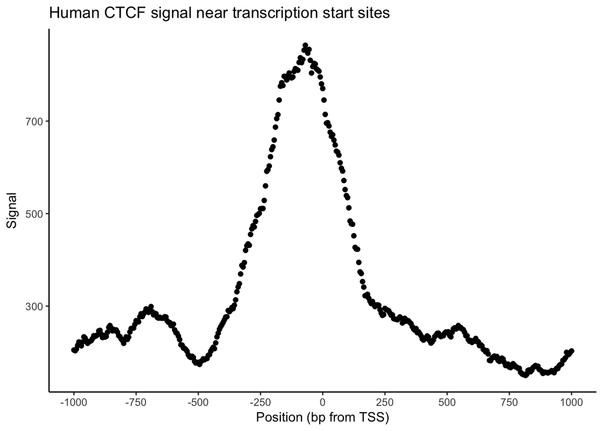

```r
library(ggplot2)

x_labels <- seq(-region_size, region_size, by = win_size * 50)
x_breaks <- seq(1, 401, by = 50)

ggplot(res, aes(x = .win_id, y = win_sum)) +
  geom_point() +
  scale_x_continuous(labels = x_labels, breaks = x_breaks) +
  xlab('Position (bp from TSS)') + ylab('Signal') +
  ggtitle('Human CTCF signal near transcription start sites') +
  theme_classic()
```

## Exercises

1. Use `valr` to generate a TSS metagene plot
2. Add a second negative control line to the metagene from shuffled TSS regions (hint: shuffle TSS positions, combine data_frames with `bind_rows()`)
3. Plot metagene with TSS’s derived from both positive and negative strands (hint: reverse negative strand interval windows)

## Contributing

If you are interested please contribute feature requests, new code, documentation, or your ideas for analysis vignettes.

https://github.com/rnabioco/valr